# White Wine Quality Exploration

### Final Plots

##### Plot 1 Alcohol and Quality

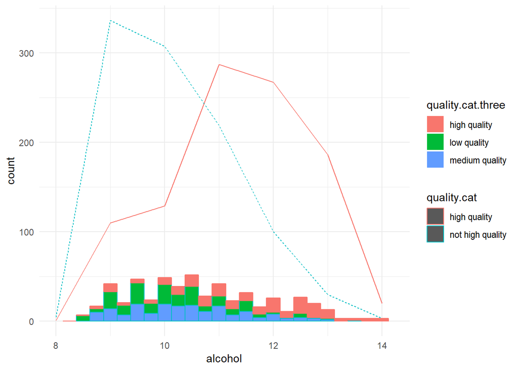

##### Plot 2 Residual Sugar, Alcohol, and Quality

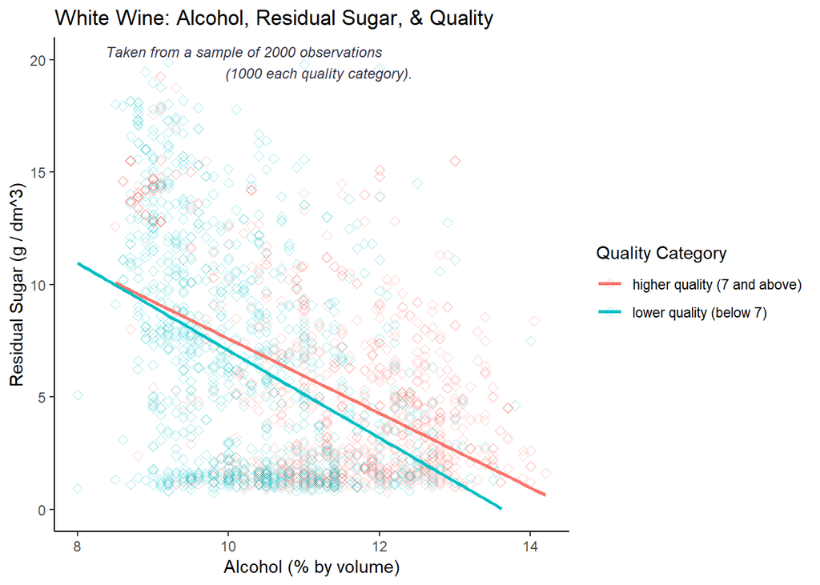

When looking at alcohol and residual sugars there’s an inverse relationship. When comparing higher quality wines with lower quality wines, the former has higher residual sugar as percent volume of alcohol increases.

##### Plot 3 Volatile Acidity, Alcohol, and Quality

[figure not shown]

Volatile acidity in medium quality wines remains pretty stable as alcohol percentage increase. For high quality wines, volatile acidity increases after about an alcohol percentage 11.5%, but the volatile acidity never reaches 0.4 For low quality wines, volatile acidity also increase at 11.5% but rather dramatically and surpasses an acidity of 0.5.

## Summary & Reflections

#### Summary

My exploration was divided into three parts-univariate, bivariate, and multivariate. In the univariate exploration, I began by looking at the counts for variables that were easily identifiable (alcohol, PH, and quality). Within the same section, I transitioned into variables that-after doing some research-I understood as corresponding to the wine’s flavor or taste (volatile acidity, citric acid, residual sugar, and chlorides).

I had made the assumption that the “flavor” variables would impact wine quality. Therefore, for the bivariate plots section, I was searching for any correlation between any of those values and the ratings for wine quality. I also discovered during this section that, of all the variables, alcohol had the strongest correlation to wine quality. In addition, I looked at the three strongest positive correlations between variables and the two strongest negative correlations.  
In the multivariate section, I took a more in-depth look into how wine quality related to various variables by grouping the wine qualities using sampling. The analysis was structured to look at wine quality and alcohol and wine quality and the flavor variables.

#### Struggles & Successes

Surprisingly, my assumption that the flavor variables would have a higher correlation to wine quality was disproved. There was no clear indication that this hypothesis was true which was disappointing to uncover. However, as the plots came to finer detail, a general pattern between lower quality and higher quality wines became discernable-values for variables for lower quality wines were spread out over a wider range and narrower for higher quality wines.

#### Moving Forward

One idea to carry this preliminary exploration forward is to apply a similar analysis to a dataset of red wine with the same variables. Here is such a one: https://www.kaggle.com/piyushgoyal443/red-wine-dataset. I’m curious whether the findings for white wine quality parallels that with red wine quality.

- Do flavor variables also have a weak correlation to red wine quality as they do for white wine quality?
- Do higher-rated red wines have variable values that are less spread out than lower-rated wines?
- Which variables have an inverse relationship to red wine quality compared to white wine quality (if any)?